# Space-Time Prediction of Bike Share Demand

Hanzhi Zhang

November 10, 2022

# 1.Introduction

With the emergence of shared bicycles, more and more problems have arisen in the city regarding shared bicycles. We can see that there are too many bikes taking up the sidewalks in the locations where bikes are parked. There is a shortage of bicycles in locations where there is a high volume of traffic and a need for more bicycles. Therefore, how to allocate shared bikes in a reasonable way has become a research problem for urban researchers.

If we can accurately predict the demand for shared bikes at different times and in different geographical locations, we can maximize the use of these resources. This is both an optimization of urban space and a convenience for bicycle users.

I think the re-balance needs to be done through the bike-sharing companies in conjunction with the city planning department. For bike-sharing companies, they can set up special transfer bicycle staff to carry out bicycle transportation. For example, transferring bikes from stations with low demand to stations with high demand at a certain point in time. For bicycle users, incentives could be provided to encourage them to park their bicycles at “Bonas Points” marked on the map to earn points. Or, a reminder to users which stations have more bikes. Considering the changes in urban traffic I think such a forecast should be in 1 hour to 2 hours increments.

## 2. Setup

Load data

```r
library(tidyverse)
library(sf)
library(lubridate)
library(tigris)
library(tidycensus)
library(viridis)
library(riem)
library(gridExtra)
library(knitr)
library(kableExtra)
library(RSocrata)
library(geojsonR)
library(geojsonio)
library(ggplot2)
library(sp)
library(gganimate)
library(gifski)

plotTheme <- theme(
  plot.title =element_text(size=12),
  plot.subtitle = element_text(size=8),
  plot.caption = element_text(size = 6),
  axis.text.x = element_text(size = 10, angle = 45, hjust = 1),
  axis.text.y = element_text(size = 10),
  axis.title.y = element_text(size = 10),
  # Set the entire chart region to blank
  panel.background=element_blank(),
  plot.background=element_blank(),
  #panel.border=element_rect(colour="#F0F0F0"),
  # Format the grid
  panel.grid.major=element_line(colour="#D0D0D0",size=.2),
  axis.ticks=element_blank())

mapTheme <- theme(plot.title =element_text(size=12),
                  plot.subtitle = element_text(size=8),
                  plot.caption = element_text(size = 6),
                  axis.line=element_blank(),
                  axis.text.x=element_blank(),
                  axis.text.y=element_blank(),
                  axis.ticks=element_blank(),
                  axis.title.x=element_blank(),
                  axis.title.y=element_blank(),
                  panel.background=element_blank(),
                  panel.border=element_blank(),
                  panel.grid.major=element_line(colour = 'transparent'),
                  panel.grid.minor=element_blank(),
                  legend.direction = "vertical",
                  legend.position = "right",
                  plot.margin = margin(1, 1, 1, 1, 'cm'),
                  legend.key.height = unit(1, "cm"), legend.key.width = unit(0.2, "cm"))

palette5 <- c("#eff3ff","#bdd7e7","#6baed6","#3182bd","#08519c")
palette4 <- c("#D2FBD4","#92BCAB","#527D82","#123F5A")
palette2 <- c("#6baed6","#08519c")
```

## Bike data

Considering the weather and holidays, I chose May 2020 as my research time.

```r
dat <- read.csv("E:\\MUSA\\5080\\8\\data\\indego-trips-2020-q2.csv")
glimpse(dat)
```

```
## Rows: 186,586
## Columns: 15
## $ trip_id             <int> 338689875, 338689874, 338689873, 338690074, 338690…
## $ duration            <int> 9, 2, 5, 19, 6, 12, 2, 7, 7, 15, 6, 10, 11, 21, 6,…
## $ start_time          <chr> "4/1/2020 0:01", "4/1/2020 0:08", "4/1/2020 1:41",…
## $ end_time            <chr> "4/1/2020 0:10", "4/1/2020 0:10", "4/1/2020 1:46",…
## $ start_station       <int> 3086, 3056, 3075, 3101, 3121, 3055, 3170, 3010, 30…
## $ start_lat           <dbl> 39.94019, 39.97669, 39.96718, 39.94295, 39.97414, …
## $ start_lon           <dbl> -75.16691, -75.15813, -75.16125, -75.15955, -75.18…
## $ end_station         <int> 3163, 3039, 3200, 3009, 3039, 3185, 3162, 3037, 31…
## $ end_lat             <dbl> 39.94974, 39.97121, 39.97583, 39.95576, 39.97121, …
## $ end_lon             <dbl> -75.18097, -75.15970, -75.16846, -75.18982, -75.15…
## $ bike_id             <int> 5420, 11961, 17699, 2525, 16707, 18555, 11737, 268…
## $ plan_duration       <int> 30, 30, 30, 30, 30, 30, 30, 30, 30, 1, 30, 30, 30,…
## $ trip_route_category <chr> "One Way", "One Way", "One Way", "One Way", "One W…
## $ passholder_type     <chr> "Indego30", "Indego30", "Indego30", "Indego30", "I…
## $ bike_type           <chr> "standard", "standard", "electric", "standard", "e…
```

Create intervals of data The data I used format is month/date/year-hour/minute.

```r
dat2 <- dat %>%
  mutate(interval60 = floor_date(mdy_hm(start_time), unit = "hour"),
         interval15 = floor_date(mdy_hm(start_time), unit = "15 mins"),
         week = week(interval60),
         dotw = wday(interval60, label=TRUE))
glimpse(dat2)
```

```
## Rows: 186,586
## Columns: 19
## $ trip_id             <int> 338689875, 338689874, 338689873, 338690074, 338690…
## $ duration            <int> 9, 2, 5, 19, 6, 12, 2, 7, 7, 15, 6, 10, 11, 21, 6,…
## $ start_time          <chr> "4/1/2020 0:01", "4/1/2020 0:08", "4/1/2020 1:41",…
## $ end_time            <chr> "4/1/2020 0:10", "4/1/2020 0:10", "4/1/2020 1:46",…
## $ start_station       <int> 3086, 3056, 3075, 3101, 3121, 3055, 3170, 3010, 30…
## $ start_lat           <dbl> 39.94019, 39.97669, 39.96718, 39.94295, 39.97414, …
## $ start_lon           <dbl> -75.16691, -75.15813, -75.16125, -75.15955, -75.18…
## $ end_station         <int> 3163, 3039, 3200, 3009, 3039, 3185, 3162, 3037, 31…
## $ end_lat             <dbl> 39.94974, 39.97121, 39.97583, 39.95576, 39.97121, …
## $ end_lon             <dbl> -75.18097, -75.15970, -75.16846, -75.18982, -75.15…
## $ bike_id             <int> 5420, 11961, 17699, 2525, 16707, 18555, 11737, 268…
## $ plan_duration       <int> 30, 30, 30, 30, 30, 30, 30, 30, 30, 1, 30, 30, 30,…
## $ trip_route_category <chr> "One Way", "One Way", "One Way", "One Way", "One W…
## $ passholder_type     <chr> "Indego30", "Indego30", "Indego30", "Indego30", "I…
## $ bike_type           <chr> "standard", "standard", "electric", "standard", "e…
## $ interval60          <dttm> 2020-04-01 00:00:00, 2020-04-01 00:00:00, 2020-04…
## $ interval15          <dttm> 2020-04-01 00:00:00, 2020-04-01 00:00:00, 2020-04…
## $ week                <dbl> 14, 14, 14, 14, 14, 14, 14, 14, 14, 14, 14, 14, 14…
## $ dotw                <ord> 周三, 周三, 周三, 周三, 周三, 周三, 周三, 周三, 周…
```

```r
bikedata <-
  dat2[dat2$week >= "18" & dat2$week <= "22",]
```

## Station data

```r
station <- geojson_read("https://kiosks.bicycletransit.workers.dev/phl.geojson",  what = "sp")
station2 <-
  st_as_sf(station)%>%
  select(id)
```

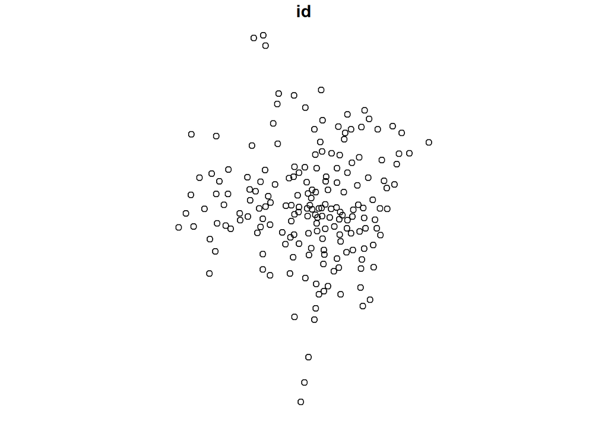

```r
par(mar=c(0,0,0,0))
plot(station2, col="black")
```

## Census data

```r
philCensus <-
  get_acs(geography = "tract",
          variables = c("B01003_001", "B19013_001",
                        "B02001_002", "B08013_001",
                        "B08012_001", "B08301_001",
                        "B08301_010", "B01002_001"),
          year = 2020,
          state = "PA",
          geometry = TRUE,
          county=c("Philadelphia"),
          output = "wide") %>%
  rename(Total_Pop =  B01003_001E,
         Med_Inc = B19013_001E,
         Med_Age = B01002_001E,
         White_Pop = B02001_002E,
         Travel_Time = B08013_001E,
         Num_Commuters = B08012_001E,
         Means_of_Transport = B08301_001E,
         Total_Public_Trans = B08301_010E) %>%
  select(Total_Pop, Med_Inc, White_Pop, Travel_Time,
         Means_of_Transport, Total_Public_Trans,
         Med_Age,
         GEOID, geometry) %>%
  mutate(Percent_White = White_Pop / Total_Pop,
         Mean_Commute_Time = Travel_Time / Total_Public_Trans,
         Percent_Taking_Public_Trans = Total_Public_Trans / Means_of_Transport)
```

```r
philTracts <-
  philCensus %>%
  as.data.frame() %>%
  distinct(GEOID, .keep_all = TRUE) %>%
  select(GEOID, geometry) %>%
  st_sf
```

```r
dat_census <- st_join(bikedata %>%
          filter(is.na(start_lon) == FALSE &
                   is.na(start_lat) == FALSE &
                   is.na(end_lat) == FALSE &
                   is.na(end_lon) == FALSE) %>%
          st_as_sf(., coords = c("start_lon", "start_lat"), crs = 4326),
        philTracts %>%
          st_transform(crs=4326),
        join=st_intersects,
              left = TRUE) %>%
  rename(Origin.Tract = GEOID) %>%
  mutate(start_lon = unlist(map(geometry, 1)),
         start_lat = unlist(map(geometry, 2)))%>%
  as.data.frame() %>%
  select(-geometry)%>%
  st_as_sf(., coords = c("end_lon", "end_lat"), crs = 4326) %>%
  st_join(., philTracts %>%
            st_transform(crs=4326),
          join=st_intersects,
          left = TRUE) %>%
  rename(Destination.Tract = GEOID)  %>%
  mutate(end_lon = unlist(map(geometry, 1)),
         end_lat = unlist(map(geometry, 2)))%>%
  as.data.frame() %>%
  select(-geometry)
```

## Weather data

Check Phildelphia weather number

```r
riem_networks()
```

```
## # A tibble: 263 × 2
##    code     name
##    <chr>    <chr>
##  1 AE__ASOS United Arab Emirates ASOS
##  2 AF__ASOS Afghanistan ASOS
##  3 AG__ASOS Antigua and Barbuda ASOS
##  4 AI__ASOS Anguilla ASOS
##  5 AK_ASOS  Alaska ASOS
##  6 AL__ASOS Albania ASOS
##  7 AL_ASOS  Alabama ASOS
##  8 AM__ASOS Armenia ASOS
##  9 AN__ASOS Netherlands Antilles ASOS
## 10 AO__ASOS Angola ASOS
## # … with 253 more rows
```

```r
riem_stations(network = "PA_ASOS")
```

```
## # A tibble: 53 × 28
##    index id    synop name    state country eleva…¹ network online county plot_…²
##    <int> <chr> <dbl> <chr>   <chr> <chr>     <dbl> <chr>   <lgl>  <chr>  <chr>
##  1     0 XLL    9999 Allent… PA    US         122  PA_ASOS TRUE   Lehigh Allent…
##  2     1 JVU    9999 Allent… PA    US         122  PA_ASOS TRUE   Lehigh Allent…
##  3     2 ABE   14737 ALLENT… PA    US         117  PA_ASOS TRUE   Lehigh <NA>
##  4     3 AOO   14736 ALTOON… PA    US         458  PA_ASOS TRUE   Bedfo… <NA>
##  5     4 BVI    4813 BEAVER… PA    US         382  PA_ASOS TRUE   Beaver <NA>
##  6     5 HMZ      NA Bedford PA    US         351. PA_ASOS TRUE   Bedfo… Bedford
##  7     6 BFD    4751 BRADFO… PA    US         653  PA_ASOS TRUE   Mckean <NA>
##  8     7 BTP   64705 BUTLER… PA    US         380  PA_ASOS TRUE   Butler <NA>
##  9     8 FIG   54792 CLEARF… PA    US         462  PA_ASOS TRUE   Clear… <NA>
## 10     9 MQS     136 Coates… PA    US         201. PA_ASOS TRUE   Chest… Coates…
## # … with 43 more rows, 17 more variables: climate_site <chr>, wfo <chr>,
## #   modified <chr>, spri <int>, tzname <chr>, iemid <int>, archive_begin <chr>,
## #   metasite <lgl>, ugc_county <chr>, ugc_zone <chr>, ncdc81 <chr>,
## #   ncei91 <chr>, longitude <dbl>, latitude <dbl>, archive_end <chr>,
## #   lon <dbl>, lat <dbl>, and abbreviated variable names ¹elevation, ²plot_name
```

```r
weather.Panel <-
  riem_measures(station = "PHL", date_start = "2020-04-29", date_end = "2020-06-02") %>%
  dplyr::select(valid, tmpf, p01i, sknt)%>%
  replace(is.na(.), 0) %>%
    mutate(interval60 = ymd_h(substr(valid,1,13))) %>%
    mutate(week = week(interval60),
           dotw = wday(interval60, label=TRUE)) %>%
    group_by(interval60) %>%
    summarize(Temperature = max(tmpf),
              Precipitation = sum(p01i),
              Wind_Speed = max(sknt)) %>%
    mutate(Temperature = ifelse(Temperature == 0, 42, Temperature))

glimpse(weather.Panel)
```

```
## Rows: 816
## Columns: 4
## $ interval60    <dttm> 2020-04-29 00:00:00, 2020-04-29 01:00:00, 2020-04-29 02…
## $ Temperature   <dbl> 55.9, 53.1, 53.1, 51.1, 51.1, 52.0, 51.1, 51.1, 51.1, 51…
## $ Precipitation <dbl> 0, 0, 0, 0, 0, 0, 0, 0, 0, 0, 0, 0, 0, 0, 0, 0, 0, 0, 0,…
## $ Wind_Speed    <dbl> 10, 10, 9, 8, 5, 7, 3, 5, 5, 7, 8, 7, 10, 11, 14, 16, 19…
```

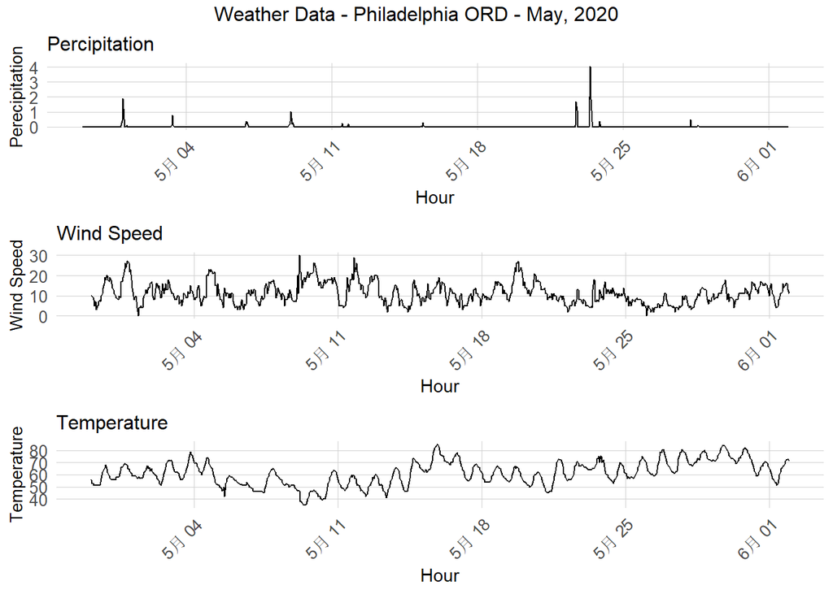

```r
grid.arrange(
  ggplot(weather.Panel, aes(interval60,Precipitation)) + geom_line() +
  labs(title="Percipitation", x="Hour", y="Perecipitation") + plotTheme,
  ggplot(weather.Panel, aes(interval60,Wind_Speed)) + geom_line() +
    labs(title="Wind Speed", x="Hour", y="Wind Speed") + plotTheme,
  ggplot(weather.Panel, aes(interval60,Temperature)) + geom_line() +
    labs(title="Temperature", x="Hour", y="Temperature") + plotTheme,
  top="Weather Data - Philadelphia ORD - May, 2020")
```

# 2. Build panel data and regression model

## 1. Describe and Explore the Data

Examining the time and frequency components of data.

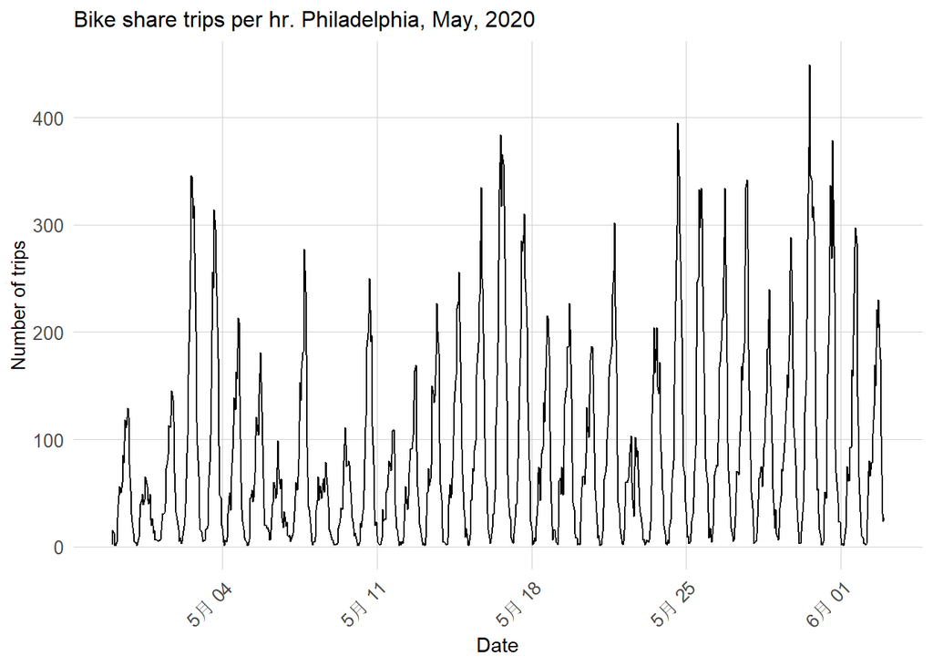

```r
ggplot(bikedata %>%
         group_by(interval60) %>%
         tally())+
  geom_line(aes(x = interval60, y = n))+
  labs(title="Bike share trips per hr. Philadelphia, May, 2020",
       x="Date",
       y="Number of trips")+
  plotTheme
```

The distribution of trip volume by station for different times of the day.

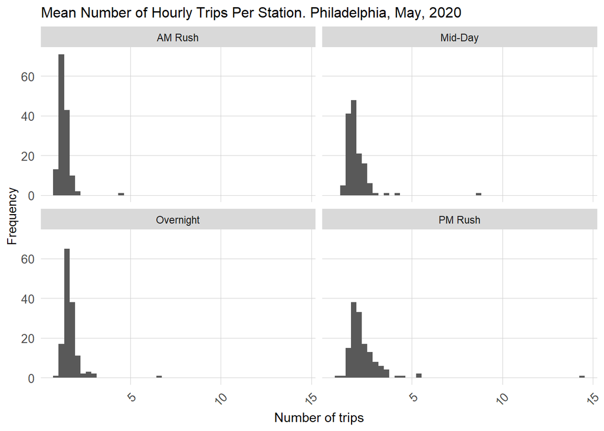

```r
bikedata %>%
        mutate(time_of_day = case_when(hour(interval60) < 7 | hour(interval60) > 18 ~ "Overnight",
                                 hour(interval60) >= 7 & hour(interval60) < 10 ~ "AM Rush",
                                 hour(interval60) >= 10 & hour(interval60) < 15 ~ "Mid-Day",
                                 hour(interval60) >= 15 & hour(interval60) <= 18 ~ "PM Rush"))%>%
         group_by(interval60, start_station, time_of_day) %>%
         tally()%>%
  group_by(start_station, time_of_day)%>%
  summarize(mean_trips = mean(n))%>%
  ggplot()+
  geom_histogram(aes(mean_trips), binwidth = 0.3)+
  labs(title="Mean Number of Hourly Trips Per Station. Philadelphia, May, 2020",
       x="Number of trips",
       y="Frequency")+
  facet_wrap(~time_of_day)+
  plotTheme
```

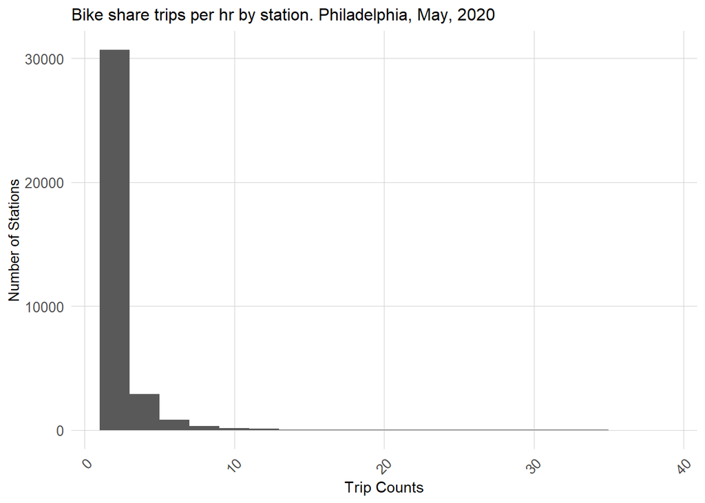

```r
ggplot(bikedata %>%
         group_by(interval60, start_station) %>%
         tally())+
  geom_histogram(aes(n), binwidth = 2)+
  labs(title="Bike share trips per hr by station. Philadelphia, May, 2020",
       x="Trip Counts",
       y="Number of Stations")+
  plotTheme
```

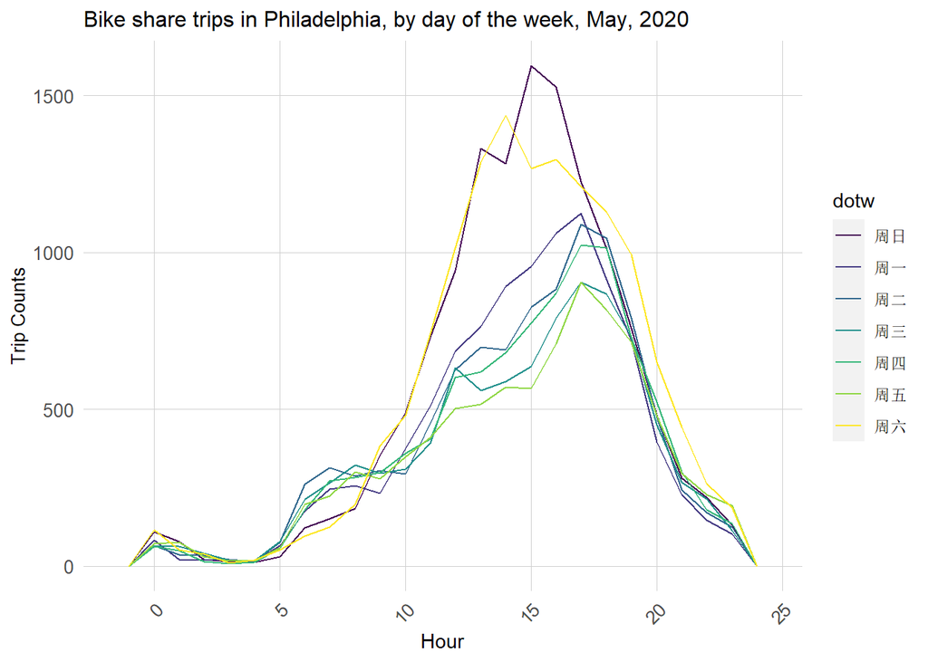

```r
ggplot(bikedata %>% mutate(hour = hour(interval60)))+
     geom_freqpoly(aes(hour, color = dotw), binwidth = 1)+
  labs(title="Bike share trips in Philadelphia, by day of the week, May, 2020",
       x="Hour",
       y="Trip Counts")+
     plotTheme
```

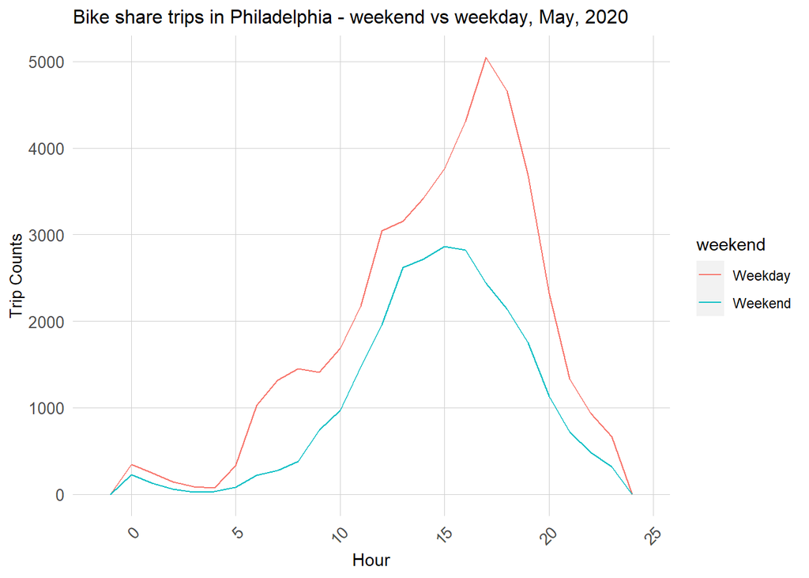

```r
ggplot(bikedata %>%
         mutate(hour = hour(interval60),
                weekend = ifelse(dotw %in% c("周日", "周六"), "Weekend", "Weekday")))+
     geom_freqpoly(aes(hour, color = weekend), binwidth = 1)+
  labs(title="Bike share trips in Philadelphia - weekend vs weekday, May, 2020",
       x="Hour",
       y="Trip Counts")+
     plotTheme
```

There is an obvious peak in downtown during mid-day and rush hour.

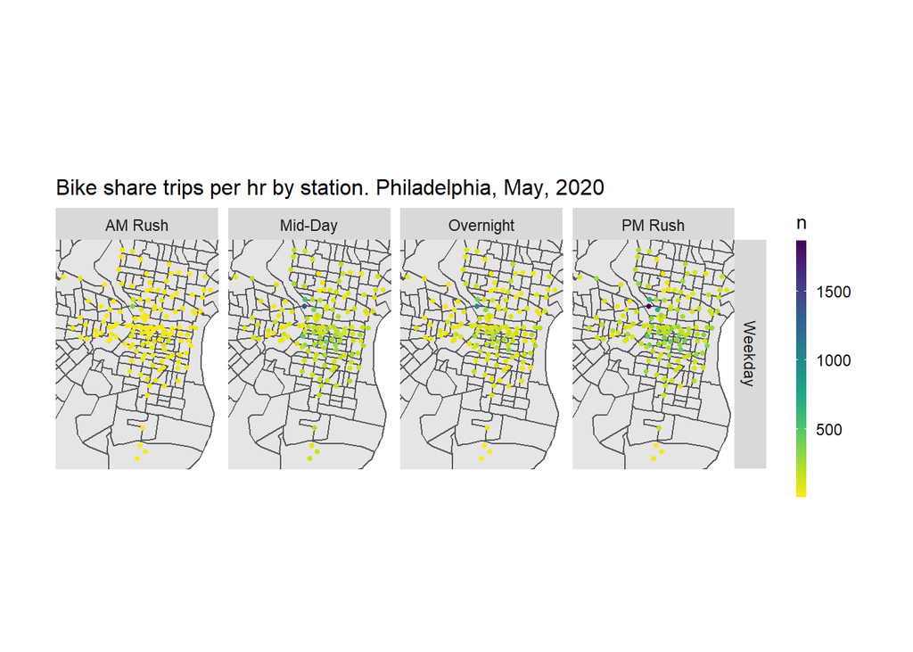

```r
ggplot()+
  geom_sf(data = philTracts %>%
          st_transform(crs=4326))+
  geom_point(data = dat_census %>%
            mutate(hour = hour(interval60),
                weekend = ifelse(dotw %in% c("Sun", "Sat"), "Weekend", "Weekday"),
                time_of_day = case_when(hour(interval60) < 7 | hour(interval60) > 18 ~ "Overnight",
                                 hour(interval60) >= 7 & hour(interval60) < 10 ~ "AM Rush",
                                 hour(interval60) >= 10 & hour(interval60) < 15 ~ "Mid-Day",
                                 hour(interval60) >= 15 & hour(interval60) <= 18 ~ "PM Rush"))%>%
              group_by(start_station, start_lat, start_lon, weekend, time_of_day) %>%
              tally(),
            aes(x=start_lon, y = start_lat, color = n),
            fill = "transparent", alpha = 1, size = 1)+
  scale_colour_viridis(direction = -1,
  discrete = FALSE, option = "D")+
  ylim(min(dat_census$start_lat), max(dat_census$start_lat))+
  xlim(min(dat_census$start_lon), max(dat_census$start_lon))+
  facet_grid(weekend ~ time_of_day)+
  labs(title="Bike share trips per hr by station. Philadelphia, May, 2020")+
  mapTheme
```